[figure not shown]

# 03 Prove - Assignment

## Objectives

- Using OpenCV to work with images

## Instructions

**Files for this project**

1. `project.py` - Your project code.
2. `testfunctions.py` - Code file that is used to test your code. Do **not** modify or submit this file.
3. `src-image1.jpg` - Image file for your project and testing.
4. `src-image2.jpg` - Image file for your project and testing.

## Functions you need to impliment

### 1) convert_image(srcfilename, dstfilename)

**Purpose:**

This function will open the image given by the argument `srcfilename`, convert it and save it to the given `dstfilename` file.

**Arguments:**

- srcfilename: source file name of the image to convert
- dstfilename: file name of the image to save the converted image

### 2) resize_image(srcfilename, dstfilename, scale)

**Purpose:**

This function will open the image given by the argument `srcfilename`, resize the image to the given scale. Then save the resulting scaled image to `dstfilename`

**Arguments:**

- srcfilename: source file name of the image to convert
- dstfilename: file name of the image to save the converted image
- scale: scale factor as an integer

### 3) border_image(srcfilename, dstfilename, width, color)

**Purpose:**

This function will open the image given by the argument `srcfilename`, enlarge it to handle the border, color the new border and save it to the given `dstfilename` file.

**Arguments:**

- srcfilename: source file name of the image to convert
- dstfilename: file name of the image to save the converted image
- width: Width of the border
- color: Color of the border as a tuple

### 4) create_mondrian()

**Purpose:**

This is the "Make it your own" challenge. You are to create a Mondrian "painting". You must have at least 5 squares in your final image. You will be graded on how close you can get to the style of what Mondrian created. Your **image** must be of your own creation - don't copy another Mondrian painting.

This function will display your completed image to the screen.

[Piet Mondrian – 'Abstract Painting as We Know It' | TateShots](https://www.youtube.com/watch?v=xkq5jQhH0WE)

Here is an example (You don't need to create a frame around the painting. However, if you can, please do):

[figure not shown]

## Images that will be created

#### Image Converting

Resulting RBG image

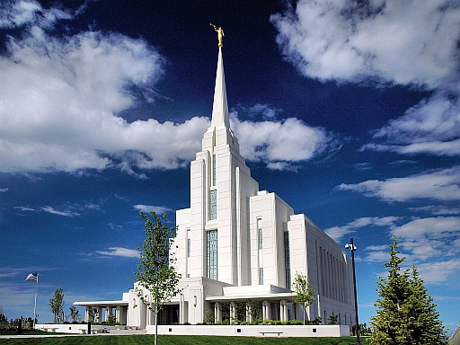

Resulting Black and White image

[figure not shown]

#### Resizing images

Resized: 50%

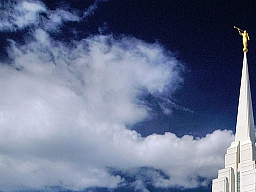

Resized: 100%

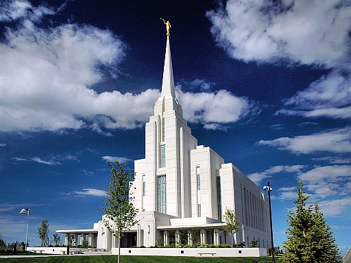

Resized: 124%

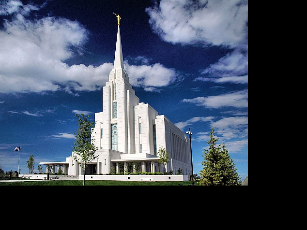

#### Borders

Border: 5 pixels

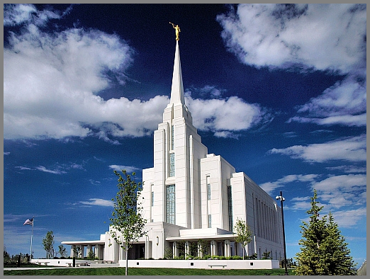

Border: 20 pixels

[figure not shown]

## Rubric

There are 8 tests that need to be passed for this project. Each test will be worth 10 points

| Task | Points |
| --- | --- |
| Test - Convert Image | 10 |
| Test - Convert Image - file exist | 10 |
| Test - Convert Image - BW | 10 |
| Test - Scale - 100 | 10 |
| Test - Scale - 50 | 10 |
| Test - Scale - 124 | 10 |
| Test - Border - 5 | 10 |
| Test - Border - 20 | 10 |
| Make it your own - Mondrian | 20 |
| ------ | ----- |
| Total | 100 |

## Submission

1. Download all of the files found at the GitHub folder `week03/assignment`
2. Write and compile your code
3. When finished, upload your `project.py` file. **Only this file!!**